# Sustainability Analytics: Energy & Weather Data Report

Barbara Maier, Wenxing Xu, Güney Usta

2025-09-26

```r
# This chunk loads all the necessary R packages for the analysis.
library(dplyr)
library(readr)
library(tidyr)
library(lubridate)
library(janitor)
library(stringr)
library(ggplot2)
library(patchwork)
library(scales)
library(kableExtra)
library(modelsummary)
library(knitr)
```

## 1. Introduction

This analysis examines historical energy and weather data from a single residence in Aarau, Switzerland. By correlating the household’s energy consumption with local weather patterns, we aim to develop data-driven recommendations to help the homeowner increase self-consumption of clean energy, reduce costs, and contribute to a more sustainable energy system.

### 1.1 Research Question

This report addresses the following primary research question:

**In what ways can a homeowner in the Canton of Aargau with a photovoltaic system make better environmental and economic decisions by leveraging their own energy data?**

## 1.2 Hypothesis

Based on this question, we formulate the following hypothesis:

A homeowner in the Canton of Aargau can significantly increase their self-consumption of solar energy and reduce grid dependency by implementing data-driven strategies, primarily by aligning flexible consumption loads, like electric vehicle (EV) charging, with peak solar production hours and employing a battery storage system to shift surplus energy to periods of demand.

## 2. Datasets & Datasources

This analysis utilizes two primary data sources: detailed energy data for the household and local weather data. The table below provides a comprehensive overview of each source.

```r
df <- data.frame(
  Dataset = c("**Household Energy Profile**", "**Historical Weather Data**"),
  Provider = c("AEW Energie AG", "MeteoSwiss"),
  Description = c(
    "High-resolution energy metrics for a residential property (Wynemattestrasse 17) over ~5 years: generation, consumption, and grid interaction.",
    "Hourly weather observations (OGD) used to correlate energy patterns with environmental conditions."
  ),
  `Key variables used` = c(
    "`pv_production_k_wh` – PV energy production (kWh)<br>`consumption_base_load_k_wh` – Base load (e.g., refrigerator, standby)<br>`consumption_heat_pump_k_wh` – Heat pump consumption<br>`consumption_ev_charging_k_wh` – EV charging consumption<br>`grid_feed_in_pv_k_wh` – Surplus PV fed into grid<br>`grid_import_total_k_wh` – Total grid import",
    "`temperature_c` – Mean air temperature (°C)<br>`humidity_pct` – Mean relative humidity (%)<br>`wind_speed_ms` – Mean wind speed (m/s)"
  ),
  stringsAsFactors = FALSE
)

kable(df, format = "html", escape = FALSE) %>%
  kable_styling(full_width = TRUE, bootstrap_options = c("striped", "hover", "condensed", "responsive"))
```

| Dataset | Provider | Description | Key.variables.used |
| --- | --- | --- | --- |
| **Household Energy Profile** | AEW Energie AG | High-resolution energy metrics for a residential property (Wynemattestrasse 17) over ~5 years: generation, consumption, and grid interaction. | `pv_production_k_wh` – PV energy production (kWh) `consumption_base_load_k_wh` – Base load (e.g., refrigerator, standby) `consumption_heat_pump_k_wh` – Heat pump consumption `consumption_ev_charging_k… |
| **Historical Weather Data** | MeteoSwiss | Hourly weather observations (OGD) used to correlate energy patterns with environmental conditions. | `temperature_c` – Mean air temperature (°C) `humidity_pct` – Mean relative humidity (%) `wind_speed_ms` – Mean wind speed (m/s) |

## 3. Data Wrangling

This section includes the functions and steps to load, clean, process, and merge the datasets.

### 3.1 Function to Load and Process Energy Data

This function is designed to handle the specific format of the AEW energy data. It correctly parses timestamps (including the “24:00” format, which is treated as the start of the next day), cleans column names, and aggregates the data to an hourly resolution.

```r
load_and_process_energy_data <- function(file_path,
                                         tz_out = "UTC",
                                         aggregate_to_hour = TRUE,
                                         complete_hours = TRUE) {

  energy_long <- read_csv(file_path, show_col_types = FALSE, guess_max = 2e5) %>%
    clean_names() %>%
    rename(ts_raw = timestamp)

  energy_wide <- energy_long %>%
    mutate(
      # Detect and handle "... 24:00" timestamps
      is_24 = str_detect(ts_raw, "(\\s|T)24:00(:00)?$"),
      ts_norm = str_replace(ts_raw, "(\\s|T)24:00(:00)?$", " 00:00:00"),
      timestamp = parse_date_time(ts_norm,
                                  orders = c("ymd HMS","ymd HM","dmy HMS","dmy HM"),
                                  tz = tz_out),
      timestamp = if_else(is_24, timestamp + days(1), timestamp),
      value = suppressWarnings(as.numeric(value))
    ) %>%
    filter(!is.na(timestamp)) %>%
    group_by(timestamp, metric) %>%
    summarise(value = mean(value, na.rm = TRUE), .groups = "drop") %>%
    pivot_wider(names_from = metric, values_from = value) %>%
    clean_names()

  if (aggregate_to_hour) {
    energy_wide <- energy_wide %>% mutate(timestamp = floor_date(timestamp, "hour"))
    kwh_cols  <- grep("_k_wh$", names(energy_wide), value = TRUE)
    other_num <- setdiff(names(energy_wide)[sapply(energy_wide, is.numeric)], kwh_cols)

    energy_wide <- energy_wide %>%
      group_by(timestamp) %>%
      summarise(
        across(all_of(kwh_cols),  ~ sum(.x, na.rm = TRUE)),
        across(all_of(other_num), ~ mean(.x, na.rm = TRUE)),
        .groups = "drop"
      )
  }

  if (complete_hours) {
    energy_wide <- energy_wide %>%
      arrange(timestamp) %>%
      complete(timestamp = seq(from = floor_date(min(timestamp), "hour"),
                               to   = floor_date(max(timestamp), "hour"),
                               by   = "hour"))
  }

  energy_wide %>%
    arrange(timestamp) %>%
    mutate(date = as_date(timestamp))
}
```

### 3.2 Function to Load and Process MeteoSwiss Weather Data

This function loads the semicolon-delimited weather data. It includes a helper to robustly parse numbers that might use either a dot or a comma as a decimal mark.

```r
# Helper to parse numbers regardless of decimal mark
parse_numeric_smart <- function(x) {
  x_chr <- as.character(x)
  v_dot   <- parse_number(x_chr, locale = locale(decimal_mark = ".", grouping_mark = ","))
  v_comma <- parse_number(x_chr, locale = locale(decimal_mark = ",", grouping_mark = "."))
  if (sum(!is.na(v_comma)) > sum(!is.na(v_dot))) v_comma else v_dot
}

load_and_process_weather_data <- function(file_path_weatherdata,
                                          station = NULL, tz_out = "UTC") {
  weather_raw <- read_delim(
    file_path_weatherdata,
    delim = ";",
    show_col_types = FALSE,
    guess_max = 2e5
  ) %>%
    clean_names() %>%
    rename(
      station       = station_abbr,
      ts_raw        = reference_timestamp,
      temperature_c = tre200h0,
      humidity_pct  = ure200h0,
      wind_speed_ms = fkl010h0
    ) %>%
    mutate(
      timestamp = parse_date_time(ts_raw, orders = c("dmy HM","dmy HMS"), tz = tz_out),
      timestamp = floor_date(timestamp, "hour"),
      date      = as_date(timestamp),
      temperature_c = parse_numeric_smart(temperature_c),
      humidity_pct  = parse_numeric_smart(humidity_pct),
      wind_speed_ms = parse_numeric_smart(wind_speed_ms)
    ) %>%
    filter(!is.na(timestamp), date >= as_date("2020-01-01"))

  weather_raw %>%
    group_by(timestamp) %>%
    summarise(
      temperature_c = mean(temperature_c, na.rm = TRUE),
      humidity_pct  = mean(humidity_pct,  na.rm = TRUE),
      wind_speed_ms = mean(wind_speed_ms, na.rm = TRUE),
      .groups = "drop"
    ) %>%
    arrange(timestamp) %>%
    mutate(date = as_date(timestamp))
}
```

### 3.3 Execute Wrangling and Merging

This chunk executes the functions defined above to load, process, and merge the two datasets into a final, hourly dataframe.

```r
# Define file paths
energy_file  <- "../data/household_energy_profile_Wynemattestrasse_17_5_years.csv"
weather_file <- "../data/ogd-smn_bus_h_historical_2020-2029.csv"

# Process data using the functions
energy_df  <- load_and_process_energy_data(energy_file)
weather_df <- load_and_process_weather_data(weather_file)

# Merge the two dataframes into one
final_df_h <- left_join(energy_df, weather_df, by = "timestamp") %>%
  select(-date.y) %>%
  rename(date = date.x)

# Display the first few rows of the final merged dataset
#head(final_df_h)

# Save the final hourly dataset to a CSV file
#write_csv(final_df_h, "final_df_h.csv")
```

### 3.4 Daily Aggregation

To analyze broader trends, we aggregate the hourly data into daily summaries. Energy metrics are summed, while weather metrics are averaged for each day.

```r
self_col <- "self_consumption_pv_k_wh"

final_df_d <- final_df_h %>%
  group_by(date) %>%
  summarise(
    # Energy (sum over 24 hours per day)
    pv_production_k_wh = sum(pv_production_k_wh, na.rm = TRUE),
    consumption_base_load_k_wh = sum(consumption_base_load_k_wh, na.rm = TRUE),
    consumption_heat_pump_k_wh = sum(consumption_heat_pump_k_wh, na.rm = TRUE),
    consumption_ev_charging_k_wh = sum(consumption_ev_charging_k_wh, na.rm = TRUE),
    consumption_cooking_lighting_etc_k_wh = sum(consumption_cooking_lighting_etc_k_wh, na.rm = TRUE),
    grid_feed_in_pv_k_wh = sum(grid_feed_in_pv_k_wh, na.rm = TRUE),
    grid_import_total_k_wh = sum(grid_import_total_k_wh, na.rm = TRUE),
    self_consumption_pv_k_wh = if (self_col %in% names(final_df_h)) sum(.data[[self_col]], na.rm = TRUE) else NA_real_,

    # Weather (daily averages)
    temperature_daily_C = mean(temperature_c, na.rm = TRUE),
    humidity_daily_pct = mean(humidity_pct, na.rm = TRUE),
    wind_speed_daily_ms = mean(wind_speed_ms, na.rm = TRUE)
  ) %>%
  ungroup()

# display the first few rows
#head(final_df_d)

# Save the daily data
#write_csv(final_df_d, "final_df_d.csv")
```

## 4. Exploratory Data Analysis (EDA)

### 4.1 Time Series Visualization: Hourly Data

The following plots show the behavior of key energy and weather variables over the entire time period. This is useful for identifying seasonality, trends, and potential anomalies.

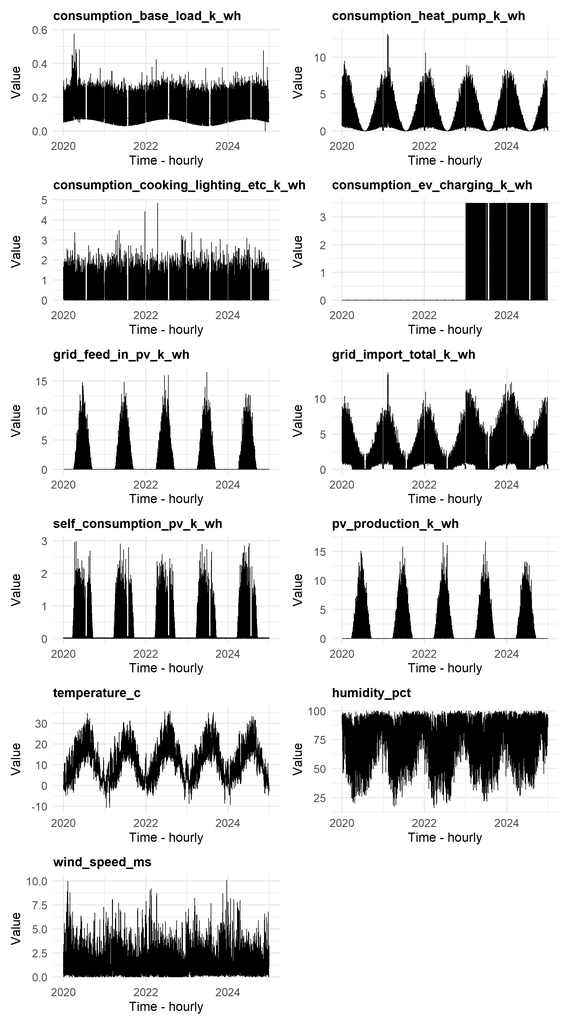

```r
# Define the list of variables to plot
plot_vars <- c(
  "consumption_base_load_k_wh", "consumption_heat_pump_k_wh", "consumption_cooking_lighting_etc_k_wh",
  "consumption_ev_charging_k_wh", "grid_feed_in_pv_k_wh",
  "grid_import_total_k_wh", "self_consumption_pv_k_wh",
  "pv_production_k_wh", "temperature_c", "humidity_pct", "wind_speed_ms"
)

# create a list of plots
plots <- lapply(plot_vars, function(var) {
  if (!var %in% names(final_df_h)) return(NULL)
  ggplot(final_df_h, aes(x = timestamp, y = .data[[var]])) +
    geom_line(linewidth = 0.5) +
    labs(title = var, x = "Time - hourly", y = "Value") +
    theme_minimal(base_size = 16) +
    theme(
      plot.title = element_text(size = 16, face = "bold"),
      axis.title = element_text(size = 16),
      axis.text = element_text(size = 14)
    )
})

# remove NULLs (in case some variables are absent)
plots <- Filter(Negate(is.null), plots)

# arrange all plots in a grid for easier comparison
wrap_plots(plots, ncol = 2)
```

As shown in the plots of consumption and grid transaction variables against hourly timestamps, there are pronounced annual seasonal patterns in several key metrics, including heat pump consumption, grid feed-in from PV, total grid import, and self-consumption of PV. These patterns are primarily driven by seasonal weather conditions. For example, heat pump consumption peaks during the winter months and reaches its lowest levels in summer. In contrast, photovoltaic (PV) production is concentrated between April and October, with output during the winter months dropping to nearly zero. This seasonal variation in PV production also shapes the dynamics of both grid feed-in and self-consumption of PV.

Additionally, the chart for EV charging consumption shows that an electric vehicle was introduced into the system starting in 2023. Ideally, EV charging demand should be aligned with PV production, so that charging is supplied as much as possible by locally generated solar electricity.

## 4.2 Time Series Visualization: Daily Data

Additionally, the hourly data is converted into daily data, enabling clearer identification of long-term seasonal patterns, reducing short-term noise, and facilitating comparisons across years.

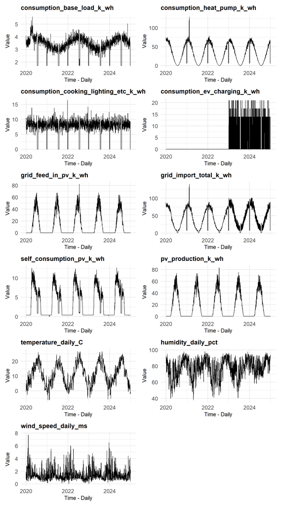

```r
# define the list of variables to plot
plot_vars_d <- c(
  "consumption_base_load_k_wh", "consumption_heat_pump_k_wh", "consumption_cooking_lighting_etc_k_wh",
  "consumption_ev_charging_k_wh", "grid_feed_in_pv_k_wh",
  "grid_import_total_k_wh", "self_consumption_pv_k_wh",
  "pv_production_k_wh", "temperature_daily_C", "humidity_daily_pct", "wind_speed_daily_ms"
)

# create a list of plots
plots <- lapply(plot_vars_d, function(var) {
  if (!var %in% names(final_df_d)) return(NULL)
  ggplot(final_df_d, aes(x = date, y = .data[[var]])) +
    geom_line(linewidth = 0.5) +
    labs(title = var, x = "Time - Daily", y = "Value") +
    theme_minimal(base_size = 16) +
    theme(
      plot.title = element_text(size = 16, face = "bold"),
      axis.title = element_text(size = 14),
      axis.text = element_text(size = 14)
    )
})

# remove NULLs (in case some variables are absent)
plots <- Filter(Negate(is.null), plots)

# arrange all plots in a grid for easier comparison
wrap_plots(plots, ncol = 2)
```

The daily plots confirm strong seasonal effects in both consumption and PV-related variables, consistent with weather-driven dynamics. Base load demand remains stable, while EV charging appears irregular and only from 2023 onward. Environmental variables show expected patterns: temperature cycles annually, humidity stays relatively stable, and wind speed is highly variable with occasional peaks.

### 4.3 Time Series Visualization Monthly Energy Balance

For the monthly balance, the hourly data was aggregated into monthly totals, separating PV production, grid transactions, and consumption categories. This aggregation smooths out daily fluctuations and highlights seasonal trends, such as higher PV generation in summer and increased heat pump demand in winter. It also makes the overall energy balance between production, self-consumption, feed-in, and imports easier to interpret.

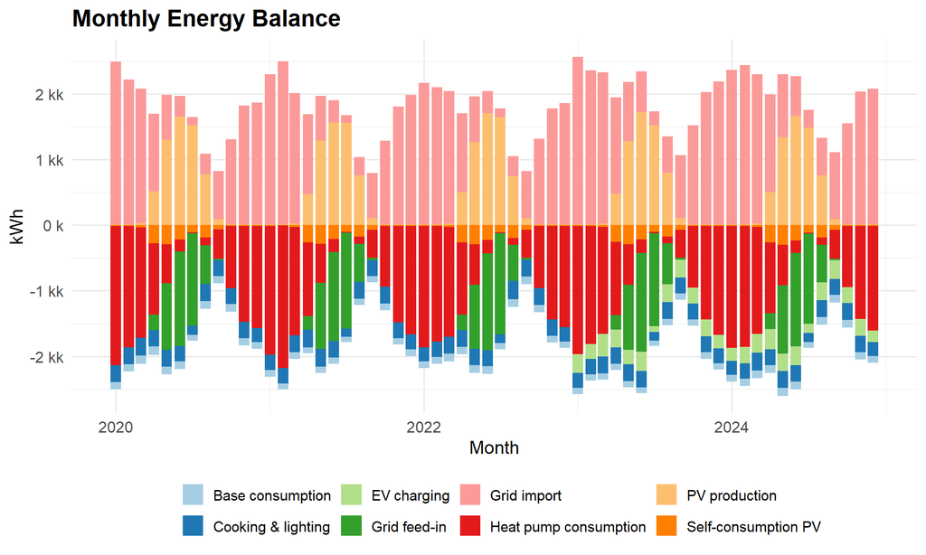

```r
# Aggregate monthly
monthly_summary <- final_df_d %>%
  mutate(year = year(date),
         month = floor_date(date, "month")) %>%
  group_by(year, month) %>%
  summarise(
    pv_production_kwh       = sum(pv_production_k_wh, na.rm = TRUE),
    grid_import_total_kwh   = sum(grid_import_total_k_wh, na.rm = TRUE),
    grid_feed_in_pv_kwh     = sum(grid_feed_in_pv_k_wh, na.rm = TRUE),
    self_consumption_pv_kwh = sum(self_consumption_pv_k_wh, na.rm = TRUE),
    consumption_base_kwh    = sum(consumption_base_load_k_wh, na.rm = TRUE),
    consumption_heat_kwh    = sum(consumption_heat_pump_k_wh, na.rm = TRUE),
    consumption_cooking_lighting_kwh = sum(consumption_cooking_lighting_etc_k_wh, na.rm = TRUE),
    consumption_ev_kwh      = sum(consumption_ev_charging_k_wh, na.rm = TRUE),
    .groups = "drop"
  )

# Reshape and set sign convention
monthly_long <- monthly_summary %>%
  pivot_longer(-c(year, month), names_to = "category", values_to = "kwh") %>%
  mutate(
    category = recode(category,
      pv_production_kwh       = "PV production",
      grid_import_total_kwh   = "Grid import",
      grid_feed_in_pv_kwh     = "Grid feed-in",
      self_consumption_pv_kwh = "Self-consumption PV",
      consumption_base_kwh    = "Base consumption",
      consumption_heat_kwh    = "Heat pump consumption",
      consumption_ev_kwh      = "EV charging",
      consumption_cooking_lighting_kwh = "Cooking & lighting"
    ),
    # Flip signs: consumption + feed-in are negative
    kwh = case_when(
      category %in% c("PV production", "Grid import") ~  kwh,
      TRUE                                           ~ -kwh
    )
  )

# Plot
ggplot(monthly_long, aes(x = month, y = kwh, fill = category)) +
  geom_col(position = "stack", width = 25) +
  scale_y_continuous(labels = label_number(scale_cut = cut_si("k"))) +
  scale_fill_brewer(palette = "Paired") +
  labs(
    title = "Monthly Energy Balance",
    x = "Month",
    y = "kWh",
    fill = " "
  ) +
  theme_minimal(base_size = 14) +
  theme(
    plot.title = element_text(size = 18, face = "bold"),
    axis.title = element_text(size = 14),
    axis.text  = element_text(size = 12),
    legend.position = "bottom"
  )
```

The monthly energy balance chart highlights the interplay between production (positive) and consumption(negative) over time. PV production dominates in the summer months, driving both higher grid feed-in and greater self-consumption, while nearly disappearing in winter. Conversely, heat pump consumption rises sharply in the colder months, contributing to increased grid import during this period. Base consumption remains relatively stable, while EV charging becomes visible only after 2023, adding irregular but notable demand. Overall, the chart illustrates strong seasonal dependencies and the complementary relationship between PV generation and energy demand.

### 4.4 Pairs Plot Weather and Energy Variables

To gain a first impression of how the weather variables influence our energy variables, we created a pairs plot that visualizes the relationships between each variable. More discuss about the pairs plot see in `6 Modeling`.

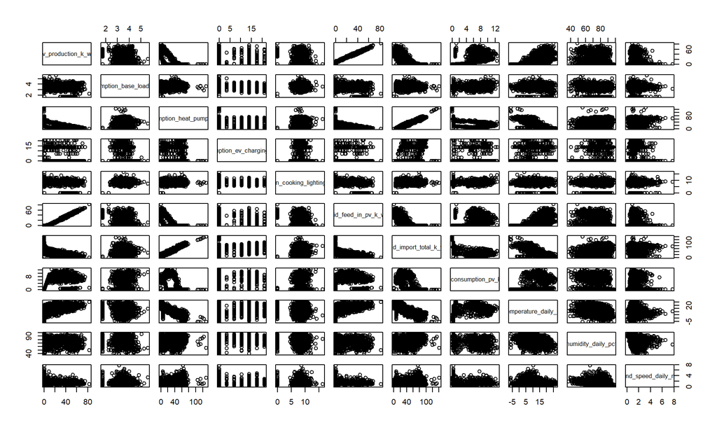

```r
# Choose only numerical variables (no date or address)
num_vars <- final_df_d[, c("pv_production_k_wh",
                           "consumption_base_load_k_wh",
                           "consumption_heat_pump_k_wh",
                           "consumption_ev_charging_k_wh",
                           "consumption_cooking_lighting_etc_k_wh",
                           "grid_feed_in_pv_k_wh",
                           "grid_import_total_k_wh",
                           "self_consumption_pv_k_wh",
                           "temperature_daily_C",
                           "humidity_daily_pct",
                           "wind_speed_daily_ms")]

# Scatterplot-Matrix
pairs(num_vars)
```

## 5. Sustainability Analysis and Optimization Strategies

### 5.1 Question 1: PV Production Efficiency

The `Daily Consumption Breakdown vs PV Production` illustrates daily breakdown of electricity consumption components—base load, heat pump, and EV charging—in relation to photovoltaic (PV) production between 2020 and 2024. Heat pump consumption displays a strong seasonal pattern, with demand peaking in the winter months and declining almost entirely during summer. In contrast, PV production follows the opposite trend, reaching its highest levels between April and October while dropping to near zero in winter. The comparison highlights a clear seasonal mismatch between PV generation and heating demand, where reliance on grid imports is greatest in winter when PV output is minimal, and opportunities for self-consumption and grid feed-in are concentrated in the sunnier months.

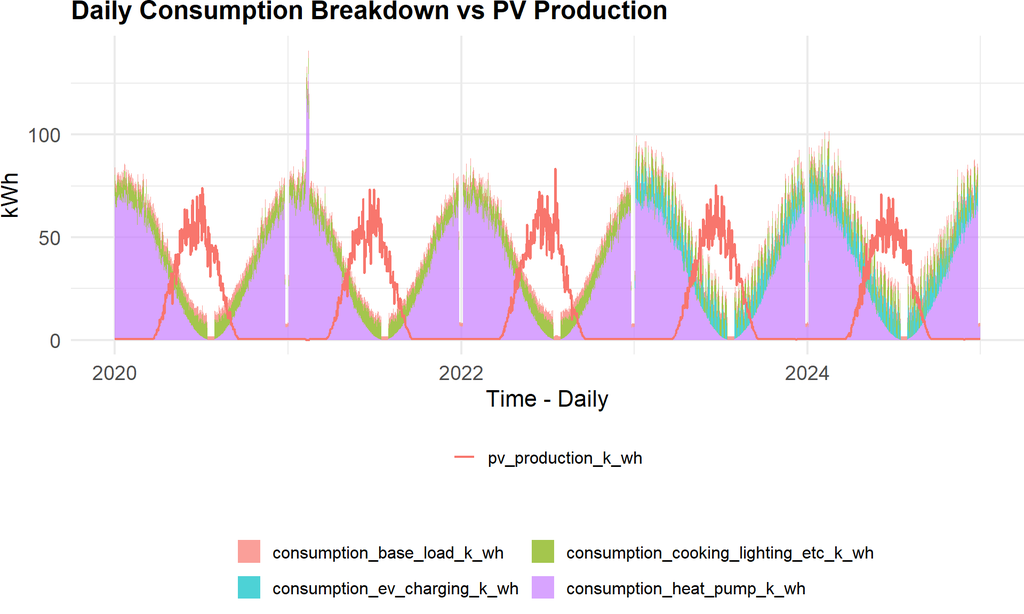

```r
plot_df <- final_df_d %>%
  select(date,
         consumption_base_load_k_wh,
         consumption_heat_pump_k_wh,
         consumption_cooking_lighting_etc_k_wh,
         consumption_ev_charging_k_wh,
         pv_production_k_wh) %>%
  pivot_longer(-date, names_to = "series", values_to = "kwh")

# Mark consumption vs PV
plot_df$type <- ifelse(grepl("consumption", plot_df$series), "Consumption", "PV")

ggplot() +
  # Stacked area for consumption
  geom_area(
    data = filter(plot_df, type == "Consumption"),
    aes(x = date, y = kwh, fill = series),
    alpha = 0.7
  ) +
  # Line for PV production
  geom_line(
    data = filter(plot_df, type == "PV"),
    aes(x = date, y = kwh, color = series),
    linewidth = 0.8
  ) +
  labs(
    title = "Daily Consumption Breakdown vs PV Production",
    x = "Time - Daily",
    y = "kWh",
    fill = " ",
    color = NULL
  ) +
  theme_minimal(base_size = 16) +
  theme(
    plot.title = element_text(size = 18, face = "bold"),
    axis.title = element_text(size = 16),
    axis.text  = element_text(size = 14),
    legend.position = "bottom",
    legend.box = "horizonal",
    legend.margin = margin(t=8),
    legend.text     = element_text(size = 12),   # legend labels
    legend.title    = element_text(size = 12),   # legend title
    plot.margin = margin(b=10)
    )+
  guides(
    fill  = guide_legend(nrow = 2, byrow = TRUE),
    color = guide_legend(nrow = 2, byrow = TRUE, order = 2)
  )
```

`Daily Consumption Breakdown vs PV Production` presents the yearly breakdown of daily consumption components compared with PV production from 2020 to 2024. The seasonal patterns remain consistent across years, with PV production peaking in summer and heat pump demand dominating in winter. However, the charts reveal that only a limited share of PV production is directly used for self-consumption, as base load and EV charging demand remain relatively small compared to the PV output during sunny months. This mismatch indicates that much of the solar generation is likely exported to the grid rather than consumed locally. Additionally, a noticeable dip in consumption between July and August suggests a vacation period, where overall demand temporarily decreases while PV generation remains high.

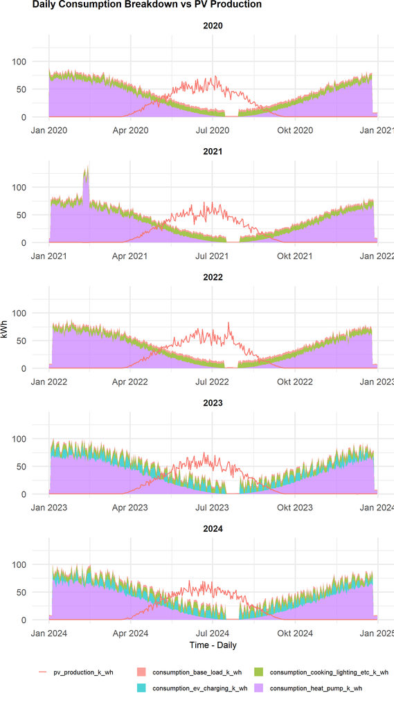

```r
plot_df <- final_df_d %>%
  mutate(year = as.integer(format(date, "%Y"))) %>%   # add year
  select(date, year,
         consumption_base_load_k_wh,
         consumption_heat_pump_k_wh,
         consumption_cooking_lighting_etc_k_wh,
         consumption_ev_charging_k_wh,
         pv_production_k_wh) %>%
  pivot_longer(-c(date, year), names_to = "series", values_to = "kwh") %>%
  mutate(type = ifelse(grepl("consumption", series), "Consumption", "PV"))

ggplot() +
  # Stacked area for consumption
  geom_area(
    data = dplyr::filter(plot_df, type == "Consumption"),
    aes(x = date, y = kwh, fill = series),
    alpha = 0.7
  ) +
  # Line for PV production
  geom_line(
    data = dplyr::filter(plot_df, type == "PV"),
    aes(x = date, y = kwh, color = series),
    linewidth = 0.8
  ) +
  labs(
    title = "Daily Consumption Breakdown vs PV Production",
    x = "Time - Daily",
    y = "kWh",
    fill = " ",
    color = NULL
  ) +
  facet_wrap(~ year, ncol = 1, scales = "free_x") +  # 5 vertical panels
  theme_minimal(base_size = 24) +
  theme(
    plot.title = element_text(size = 18, face = "bold"),
    axis.title = element_text(size = 16),
    axis.text  = element_text(size = 16),
    strip.text = element_text(size = 16, face = "bold"),
    legend.position = "bottom",      # outside the plot area
    legend.box = "horizontal",
    legend.margin = margin(t = 8),
    legend.text     = element_text(size = 12),   # legend labels
    #legend.title    = element_text(size = 12),   # legend title
    plot.margin = margin(b = 30)
  ) +
  guides(
    fill  = guide_legend(nrow = 2, byrow = TRUE),
    color = guide_legend(nrow = 2, byrow = TRUE, order = 2)
  )
```

The table `Seasonal PV Production by Year` shows that autumn and winter PV production is extremely low, about 0–3% of the summer level each year, almost negligible output during 6 months, while spring production reaches roughly 43–48% of summer. Several sources estimate that PV systems in temperate latitudes produce 40–60% less energy in winter than in summer. For example, Lighthouse Solar reports a drop of 40-60% for solar power in December/January compared to July/August Solar (2017). In comparison, the winter PV production in our case is significantly lower than the average expectation, suggesting potential system or site-specific inefficiencies. There are several possible explanations:

- The solar panels may be mounted at a tilt angle optimized for summer sun but not ideal for capturing low-angle winter sunlight, which reduces winter generation dramatically Nahim et al. (2025); U.S. Department of Energy (2023).
- In addition, weather factors such as cloud cover, snow, and shorter daylight hours further cut winter production Amusan & Otokunefor (2019); Mokhtari et al. (2021).
- Panel efficiency under cold, low-light conditions might also be less than expected, if the equipment or orientation isn’t optimized for those conditions Sarmah et al. (2023); Shaker et al. (2024).

```r
# Define seasons manually
get_season <- function(dates) {
  m <- month(dates)
  ifelse(m %in% 3:5,  "Spring",
  ifelse(m %in% 6:8,  "Summer",
  ifelse(m %in% 9:11, "Autumn", "Winter")))
}

# build table (numeric, rounded)
season_summary_tbl <- final_df_d %>%
  mutate(year = year(date),
         season = get_season(date)) %>%
  group_by(year, season) %>%
  summarise(pv_total_kwh = sum(pv_production_k_wh, na.rm = TRUE), .groups = "drop") %>%
  group_by(year) %>%
  mutate(ratio_to_summer = pv_total_kwh / max(pv_total_kwh, na.rm = TRUE) * 100) %>%
  ungroup() %>%
  mutate(
    # order seasons
    season = factor(season, levels = c("Spring","Summer","Autumn","Winter")),
    pv_total_kwh    = round(pv_total_kwh, 2),
    ratio_to_summer = round(ratio_to_summer, 2)
  ) %>%
  arrange(year, season)

# table with kableExtra
season_summary_tbl %>%
  mutate(year = as.character(year)) %>%
  knitr::kable(
    caption = "Seasonal PV Production by Year",
    col.names = c("Year", "Season", "PV total (kWh)", "Ratio to Summer (%)"),
    align = c("c","l","r","r"),
    booktabs = TRUE,
    format.args = list(big.mark = ",", scientific = FALSE)
  ) %>%
  kableExtra::kable_styling(full_width = T, bootstrap_options = c("striped","hover")) %>%
  kableExtra::collapse_rows(columns = 1, valign = "top")
```

Seasonal PV Production by Year

| Year | Season | PV total (kWh) | Ratio to Summer (%) |
| --- | --- | --- | --- |
| 2020 | Spring | 1,852.79 | 46.87 |
|  | Summer | 3,952.83 | 100.00 |
|  | Autumn | 110.71 | 2.80 |
|  | Winter | 32.76 | 0.83 |
| 2021 | Spring | 1,786.12 | 45.88 |
|  | Summer | 3,892.70 | 100.00 |
|  | Autumn | 126.82 | 3.26 |
|  | Winter | 30.19 | 0.78 |
| 2022 | Spring | 1,794.37 | 43.80 |
|  | Summer | 4,097.13 | 100.00 |
|  | Autumn | 124.67 | 3.04 |
|  | Winter | 32.40 | 0.79 |
| 2023 | Spring | 1,791.94 | 44.36 |
|  | Summer | 4,039.82 | 100.00 |
|  | Autumn | 126.36 | 3.13 |
|  | Winter | 32.21 | 0.80 |
| 2024 | Spring | 1,872.31 | 47.84 |
|  | Summer | 3,913.31 | 100.00 |
|  | Autumn | 112.78 | 2.88 |
|  | Winter | 32.76 | 0.84 |

**Optimization Suggestions:** Based on the PV production analysis, the results indicate that the solar panels generate substantially less energy during the autumn and winter seasons compared to reference in the same region. This points to a fundamental inefficiency in the current system configuration. Consequently, there is considerable potential for optimization. Possible strategies include:

- Adjusting panel tilt or orientation to better capture low-angle winter sunlight, or considering dual-tilt/adjustable mounting systems.
- Installing higher-efficiency modules designed for low-light conditions, which can improve energy yield during cloudy or short-day periods.
- Regular maintenance and snow management to prevent shading or coverage that can drastically reduce winter output.
- Integrating storage solutions (e.g., batteries) or load shifting strategies to maximize the use of PV energy when production is highest.

Implementing such measures could reduce the seasonal mismatch between generation and demand, improve self-consumption, and increase the overall sustainability and resilience of the system.

### 5.2 Question 2: EV Charing Efficiency

The introduction of an EV in 2023 presents a major opportunity to increase self-consumption. The key is to align its charging schedule with peak PV production. The plots below explore the energy balance and how the EV fits in.

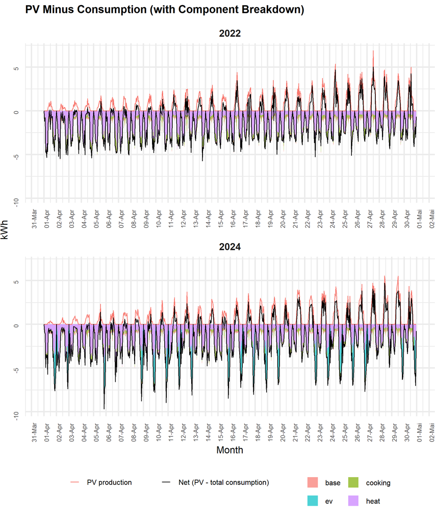

```r
# ---- Prepare data for Plot 3 ----
df3 <- final_df_h %>%
  mutate(year = year(timestamp), month = month(timestamp)) %>%
  # choose your window: Apr–Jul; change to month == 4 if you only want April
  filter(year %in% c(2022, 2024), month == 4) %>%
  transmute(
    timestamp, year,
    base = consumption_base_load_k_wh,
    heat = consumption_heat_pump_k_wh,
    cooking = consumption_cooking_lighting_etc_k_wh,
    ev   = consumption_ev_charging_k_wh,
    pv   = pv_production_k_wh
  ) %>%
  mutate(across(c(base, heat, cooking, ev, pv), ~replace_na(., 0)),
         total_cons = base + heat + cooking + ev,
         net = pv - total_cons)

# Consumption components (as negatives for stacking)
cons_long <- df3 %>%
  select(timestamp, year, base, heat, cooking, ev) %>%
  pivot_longer(-c(timestamp, year), names_to = "component", values_to = "kwh") %>%
  mutate(kwh = -kwh)   # show below zero

# ---- Plot 3: PV – Consumption (with breakdown) ----
p_balance <- ggplot() +
  # stacked negative areas = consumption breakdown
  geom_area(
    data = cons_long,
    aes(x = timestamp, y = kwh, fill = component),
    alpha = 0.7
  ) +
  # PV production as a line (positive)
  geom_line(
    data = df3,
    aes(x = timestamp, y = pv, color = "PV production"),
    linewidth = 0.6
  ) +
  # Net balance line
  geom_line(
    data = df3,
    aes(x = timestamp, y = net, linetype = "Net (PV - total consumption)"),
    linewidth = 0.7
  ) +
  facet_wrap(~ year, ncol = 1, scales = "free_x") +
  scale_x_datetime(date_breaks = "1 day", date_labels = "%d-%b") +
  labs(
    title = "PV Minus Consumption (with Component Breakdown)",
    x = "Month",
    y = "kWh",
    fill = " ",
    color = NULL,
    linetype = NULL
  ) +
  theme_minimal(base_size = 24) +
  theme(
    plot.title = element_text(size = 18, face = "bold"),
    axis.title = element_text(size = 16),
    axis.text  = element_text(size = 10, angle = 90),
    strip.text = element_text(size = 16, face = "bold"),
    legend.position = "bottom",
    legend.box = "horizontal",
    legend.text = element_text(size = 12),
    legend.title = element_text(size = 12),
    plot.margin = margin(t = 8, b = 14)
  ) +
  guides(
    linetype = guide_legend(nrow = 2, byrow = TRUE),
    fill     = guide_legend(nrow = 2, byrow = TRUE, override.aes = list(size = 6)),
    color    = guide_legend(nrow = 2, byrow = TRUE, order = 3)
  )
# If you already have p_cons and p_pv from earlier:
# p_cons / p_pv / p_balance

p_balance
```

The comparison of April 2022 (before EV adoption) and April 2024 (after EV introduction) highlights the impact of EV charging on household energy balance. In April 2024, EV charging accounted for roughly 18% of total household electricity consumption, representing a significant new load on the system. Importantly, most charging sessions occurred between 9 pm and 3 am, a period without PV production, which led to a strongly negative net balance and increased reliance on grid imports. This highlights a clear optimization opportunity: shifting charging into daylight hours could allow EV demand to be met by self-generated solar energy, improving self-consumption and reducing grid dependency.

The table `EV Charging Share of Total Household Consumption (%)` summarizes the monthly share of household electricity consumption attributed to EV charging in 2023 and 2024. In both years, EV charging demand is relatively low during the winter months (8–12%), but it rises sharply in summer, peaking at 37.0% in August 2023 and 35.6% in August 2024. This strong seasonal pattern indicates that EV charging makes up over one-third of total household electricity use in summer, while in winter it remains closer to 10% of the load.

```r
# ---- Prepare monthly EV share ----
ev_monthly_pct <- final_df_h %>%
  filter(year(timestamp) %in% c(2023, 2024)) %>%
  mutate(year  = year(timestamp),
         month = month(timestamp, label = TRUE, abbr = TRUE)) %>%
  group_by(year, month) %>%
  summarise(
    ev_total   = sum(consumption_ev_charging_k_wh,           na.rm = TRUE),
    base_total = sum(consumption_base_load_k_wh,             na.rm = TRUE),
    heat_total = sum(consumption_heat_pump_k_wh,             na.rm = TRUE),
    cook_total = sum(consumption_cooking_lighting_etc_k_wh,  na.rm = TRUE),
    .groups = "drop"
  ) %>%
  mutate(
    total_cons = ev_total + base_total + heat_total + cook_total,
    ev_pct     = round(100 * ev_total / total_cons, 2)
  ) %>%
  select(year, month, ev_pct) %>%
  arrange(year, month)

# ---- Render as table ----
ev_monthly_pct %>%
  tidyr::pivot_wider(names_from = month, values_from = ev_pct) %>%
  kable(
    caption = "EV Charging Share of Total Household Consumption (%)",
    col.names = c("Year", month.abb),
    align = c("c", rep("r", 12)),
    booktabs = TRUE
  ) %>%
  kable_styling(full_width = FALSE, bootstrap_options = c("striped", "hover"))
```

EV Charging Share of Total Household Consumption (%)

| Year | Jan | Feb | Mar | Apr | May | Jun | Jul | Aug | Sep | Oct | Nov | Dec |
| --- | --- | --- | --- | --- | --- | --- | --- | --- | --- | --- | --- | --- |
| 2023 | 11.04 | 9.80 | 15.03 | 15.63 | 18.47 | 34.88 | 28.69 | 37.02 | 26.05 | 15.61 | 12.40 | 9.26 |
| 2024 | 8.26 | 10.05 | 12.61 | 17.59 | 21.12 | 33.24 | 35.55 | 35.60 | 26.33 | 15.79 | 12.73 | 8.22 |

The chart `Annual PV Production Breakdown with Grid Import Overlay` compares PV production (split into self-consumption and grid feed-in) with total grid imports from 2020 to 2024. PV production remains relatively stable at around 5,800–6,000 kWh annually, with no significant increase in self-consumption across the years.

This highlights a critical inefficiency: EV charging demand is not aligned with PV generation, leaving the household more dependent on external electricity sources despite stable solar output.

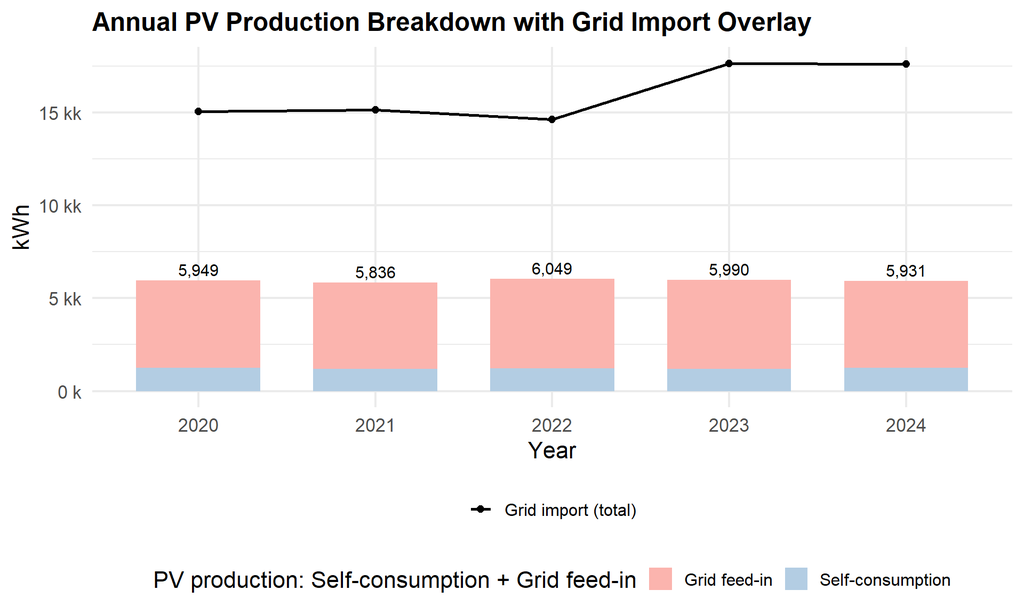

```r
#  Aggregate hourly -> annual
annual <- final_df_h %>%
  mutate(year = lubridate::year(timestamp)) %>%
  group_by(year) %>%
  summarise(
    pv_production_k_wh       = sum(pv_production_k_wh,       na.rm = TRUE),
    self_consumption_pv_k_wh = sum(self_consumption_pv_k_wh, na.rm = TRUE),
    grid_feed_in_pv_k_wh     = sum(grid_feed_in_pv_k_wh,     na.rm = TRUE),
    grid_import_total_k_wh   = sum(grid_import_total_k_wh,   na.rm = TRUE),
    .groups = "drop"
  ) %>%
  mutate(check_diff_kwh = pv_production_k_wh -
           (self_consumption_pv_k_wh + grid_feed_in_pv_k_wh))

# Long format for stacked bars
bars_long <- annual %>%
  select(year, self_consumption_pv_k_wh, grid_feed_in_pv_k_wh) %>%
  pivot_longer(-year, names_to = "component", values_to = "kwh") %>%
  mutate(component = dplyr::recode(
    component,
    self_consumption_pv_k_wh = "Self-consumption",
    grid_feed_in_pv_k_wh     = "Grid feed-in"
  ))

# Plot
ggplot() +
  geom_col(
    data = bars_long,
    aes(x = factor(year), y = kwh, fill = component),
    position = "stack", width = 0.7
  ) +
  geom_text(
    data = annual,
    aes(x = factor(year),
        y = pv_production_k_wh,
        label = scales::comma(round(pv_production_k_wh))),
    vjust = -0.4, size = 4
  ) +
  geom_line(
    data = annual,
    aes(x = factor(year), y = grid_import_total_k_wh,
        group = 1, color = "Grid import (total)"),
    linewidth = 1
  ) +
  geom_point(
    data = annual,
    aes(x = factor(year), y = grid_import_total_k_wh,
        color = "Grid import (total)"),
    size = 2.2
  ) +
  scale_y_continuous(labels = scales::label_number(
    scale_cut = scales::cut_si("k"))) +
  scale_fill_brewer(palette = "Pastel1") +
  scale_color_manual(values = c("Grid import (total)" = "black")) +
  labs(
    title = "Annual PV Production Breakdown with Grid Import Overlay",
    x = "Year",
    y = "kWh",
    fill = "PV production: Self-consumption + Grid feed-in",
    color = NULL
  ) +
  theme_minimal(base_size = 16) +
  theme(
    plot.title = element_text(size = 18, face = "bold"),
    legend.position = "bottom",
    legend.box = "vertical",
    legend.text = element_text(size = 12)
  )
```

**Optimization Suggestions:** - Shift Charging to Daytime Hours: Most EV charging currently occurs at night (9 pm–3 am), when PV production is zero. Rescheduling charging to mid-day (10 am–4 pm), especially in spring and summer, would allow a significant portion of the EV demand to be met directly from PV generation Fachrizal et al. (2020).

- Smart Charging / Automated Scheduling: Use smart chargers or time-based charging programs to automatically prioritize charging during periods of surplus solar output Ye et al. (2024). This reduces reliance on grid imports and minimizes energy wasted in feed-in (low compensation tariffs).
- Flexible Charging Strategies: Instead of fully charging the EV overnight, apply partial daytime charging when PV is available. Example: If the EV is parked at home during work-from-home days or weekends, charge incrementally during peak PV hours.
- Battery Storage Integration: If daily charging flexibility is limited (e.g., car is absent during daytime), adding a home battery could store excess solar from mid-day and discharge it during evening EV charging. This increases PV self-consumption not only for the EV but also for other household loads Gu et al. (2025), Ullner et al. (2025).
- Dynamic Tariff and Grid Optimization: Combine smart charging with real-time electricity price signals, Use cheap off-peak grid electricity at night only when PV availability is insufficient. Prioritize solar charging whenever possible to reduce long-term electricity costs.

### 5.3 Battery Storage Potential

To assess the viability of a battery storage system, we need to understand the daily energy surplus and deficit. A surplus occurs when PV production exceeds total household consumption, and this excess energy could be used to charge a battery instead of being sold to the grid. A deficit occurs when consumption is higher than production, requiring energy from the grid or, potentially, from a battery.

The plot below calculates the total surplus (charge potential) and deficit (discharge demand) for each day over the entire period.

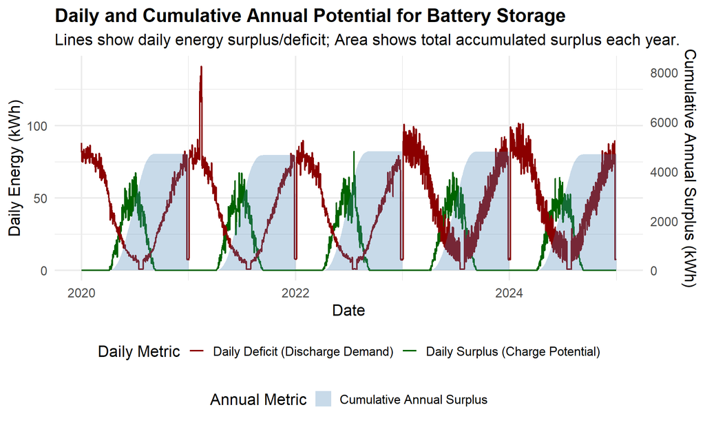

```r
# 1. Define all possible consumption columns
# This list now correctly includes the "cooking & lighting" category.
consumption_cols <- c(
  "consumption_base_load_k_wh",
  "consumption_heat_pump_k_wh",
  "consumption_ev_charging_k_wh",
  "consumption_cooking_lighting_etc_k_wh"
)

# 2. Find which of these columns actually exist in your dataframe
existing_consumption_cols <- intersect(consumption_cols, names(final_df_h))

# 3. Stop with a clear error message if no consumption data is found
if (length(existing_consumption_cols) == 0) {
  stop("CRITICAL ERROR: No consumption columns found in the data. Please check the input file.")
}

# 4. Calculate hourly net energy using a robust method
hourly_net <- final_df_h %>%
  # First, ensure all numeric columns have no NA values
  mutate(across(where(is.numeric), ~replace_na(., 0))) %>%
  # Now, calculate total consumption by summing ONLY the columns that exist.
  # This use of rowSums() is the key to making the code robust.
  mutate(
    total_consumption = rowSums(select(., all_of(existing_consumption_cols))),
    net_kwh = pv_production_k_wh - total_consumption
  )

# 5. Aggregate to find daily surplus (charge potential) and deficit (discharge demand)
daily_battery_potential <- hourly_net %>%
  group_by(date) %>%
  summarise(
    charge_potential_kwh = sum(net_kwh[net_kwh > 0], na.rm = TRUE),
    discharge_demand_kwh = abs(sum(net_kwh[net_kwh < 0], na.rm = TRUE)),
    .groups = "drop"
  ) %>%
  arrange(date) %>%
  group_by(year = year(date)) %>%
  mutate(cumulative_surplus_kwh = cumsum(charge_potential_kwh)) %>%
  ungroup()

# 6. Define the scaling factor for the secondary y-axis (with safety check)
max_charge_potential <- max(daily_battery_potential$charge_potential_kwh, na.rm = TRUE)
scaling_factor <- if (is.finite(max_charge_potential) && max_charge_potential > 0) {
  max(daily_battery_potential$cumulative_surplus_kwh, na.rm = TRUE) / max_charge_potential
} else {
  1 # Default to 1 if no valid charge potential exists to prevent errors
}

# 7. Plot the results
ggplot(daily_battery_potential, aes(x = date)) +
  geom_line(aes(y = charge_potential_kwh, color = "Daily Surplus (Charge Potential)"), linewidth = 0.8) +
  geom_line(aes(y = discharge_demand_kwh, color = "Daily Deficit (Discharge Demand)"), linewidth = 0.8) +
  geom_area(aes(y = cumulative_surplus_kwh / scaling_factor, fill = "Cumulative Annual Surplus"), alpha = 0.3) +
  scale_y_continuous(
    name = "Daily Energy (kWh)",
    sec.axis = sec_axis(~ . * scaling_factor, name = "Cumulative Annual Surplus (kWh)")
  ) +
  scale_color_manual(
    name = "Daily Metric",
    values = c("Daily Surplus (Charge Potential)" = "darkgreen", "Daily Deficit (Discharge Demand)" = "darkred")
  ) +
  scale_fill_manual(
    name = "Annual Metric",
    values = c("Cumulative Annual Surplus" = "steelblue")
  ) +
  labs(
    title = "Daily and Cumulative Annual Potential for Battery Storage",
    subtitle = "Lines show daily energy surplus/deficit; Area shows total accumulated surplus each year.",
    x = "Date",
    y = "Daily Energy (kWh)"
  ) +
  theme_minimal(base_size = 16) +
  theme(
    legend.position = "bottom",
    legend.box = "vertical",
    plot.title = element_text(face = "bold")
  )
```

The plot clearly shows the same strong seasonal pattern observed earlier.

- Charge Potential (Green Line): During summer, there are frequent days with over 20 kWh of surplus energy—energy that is currently being fed to the grid but could be stored in a battery. This potential disappears almost completely in winter.
- Discharge Demand (Red Line): This represents the energy needed from the grid (or a battery) when PV is not producing. In summer, the daily deficit is relatively low, often under 10 kWh, covering evening and nighttime loads. In winter, this deficit skyrockets due to the heat pump, far exceeding any potential for charging.

Recommendations for Battery System: Based on the analysis, a residential battery storage system is a highly recommended investment for this household.

Recommended Capacity: **10-15 kWh.**

Operational Strategy:

- Charging: The system should be programmed to prioritize charging from surplus solar energy during peak production hours (approx. 10 AM to 4 PM).
- Discharging: The battery should discharge to cover the household load when solar production ceases in the late afternoon and overnight. This maximizes self-consumption.
- EV Charging Integration: Integrating the EV charger with the battery system would be ideal. The system could be set to charge the EV from solar surplus first, then use any remaining surplus to charge the home battery.

## 6. Modeling

The pairs plot in `4.4`shows several important relationships. PV production and grid feed-in PV are strongly correlated, which is expected because excess solar power is usually fed directly into the grid. Heat pump consumption shows a clear negative relationship with temperature: when the weather is warmer, the heat pump uses less energy. In contrast, PV production is positively related to temperature, as higher temperatures generally coincide with more sunlight. Other variables such as humidity and wind speed do not show strong patterns with consumption or production. Based on these observations, temperature was chosen as the main predictor variable later for the dashboard, since it is strongly linked to both heat pump consumption and PV production.

Motivation for linear regression: The scatterplot matrix indicated that temperature has the strongest effect on both PV production and heat pump consumption, while other weather variables showed little influence. Therefore, we applied simple linear regression models using daily temperature as the predictor.

Although more advanced models could potentially achieve higher accuracy, many of the variables required for such approaches (e.g., solar irradiance) were not available in our dataset. Therefore, linear regression was chosen as a suitable compromise: simple, interpretable, and appropriate given the limited input variables.

```r
#Linear Model
model_hp <- lm(consumption_heat_pump_k_wh ~ temperature_daily_C, data = final_df_d)


model_pv <- lm(pv_production_k_wh ~ temperature_daily_C, data = final_df_d)

#Output table
modelsummary(
  list("Heat Pump Consumption" = model_hp,
       "PV Production" = model_pv),
  stars = TRUE,
  statistic = "std.error",
  gof_omit = "IC|Log|F",
  output = "gt",
  coef_map = c("(Intercept)" = "Intercept",
               "temperature_daily_C" = "Temperature (°C)")
)
```

|  | Heat Pump Consumption | PV Production |
| --- | --- | --- |
| Intercept | 64.879*** | -6.193*** |
|  | (0.556) | (0.675) |
| Temperature (°C) | -2.893*** | 2.020*** |
|  | (0.042) | (0.051) |
| Num.Obs. | 1827 | 1827 |
| R2 | 0.723 | 0.463 |
| R2 Adj. | 0.722 | 0.463 |
| RMSE | 12.87 | 15.63 |

+ p < 0.1, * p < 0.05, ** p < 0.01, *** p < 0.001

#### Results of the regression models

The regression of heat pump consumption on daily temperature shows a strong negative relationship (β = –2.89, p < 0.001, R² = 0.72). This confirms that warmer days lead to substantially lower heating demand. For PV production, the model indicates a positive relationship with temperature (β = 2.02, p < 0.001, R² = 0.46), meaning that higher temperatures are generally associated with higher solar output.

*Limitations* To make truly accurate predictions of heat pump consumption and PV production, information on solar radiation would be required. Since this key variable is missing in our dataset, we relied on temperature as the main predictor. If solar radiation data were available, a more complex model than simple linear regression would likely be necessary to capture the additional effects. Given the current data, however, we proceed with the linear regression approach.

## 7. Dashboard

The motivation for creating the dashboard was to provide a practical tool for homeowners, making their energy use visible and thus more transparent, so they can better understand and adapt their behavior accordingly.

It consists of four main views: a daily perspective, an hourly perspective, a forecast view, and a page with analytics.

We decided to include only a few key variables to keep it clear and easy to understand. We chose Heat Pump Consumption because, compared to the other variables, it accounts for the highest energy use — almost as if we were showing the entire energy consumption of the house. In addition, we included PV Production and Electric Vehicle consumption, since they represent major and highly variable factors in the household’s overall energy balance.

Together, these pages illustrate how temperature affects both PV production and heat pump consumption, and how future values can be estimated based on weather forecasts. In the following sections, each dashboard view is presented, along with an explanation of the steps taken to create them in Tableau.

### 7.1 Dashboard Daily View

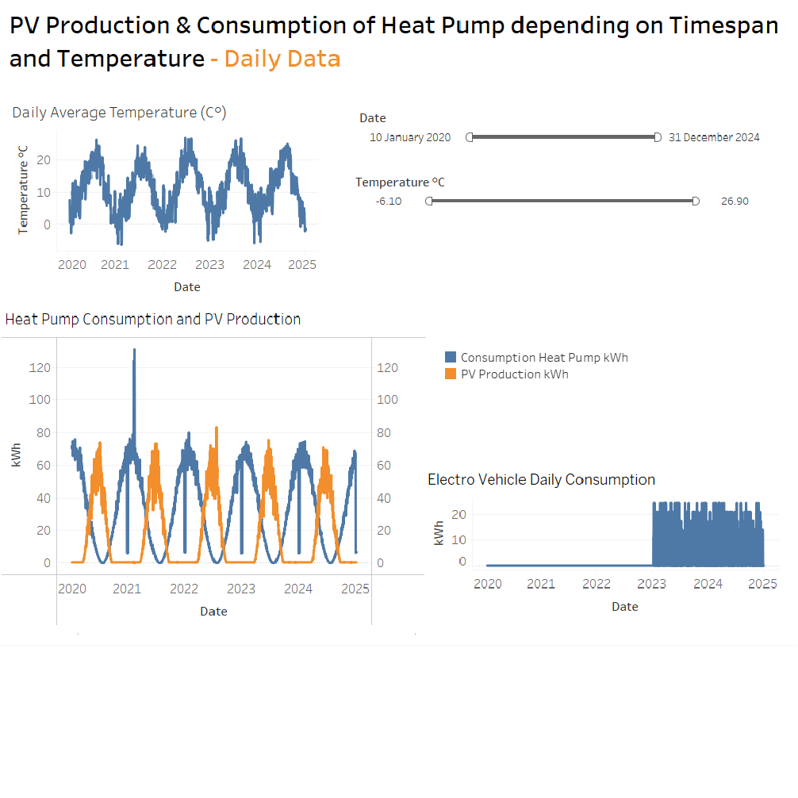

```r
knitr::include_graphics("images/dayly_few.png")
```

To create the Daily View Dashboard, the dataset final_df_d was imported into Tableau.

The key variables chosen were Temperature, PV Production, and Heat Pump Consumption, since these showed the strongest correlations in the earlier analysis. Interactive filters for Date and Temperature were added to allow the house owner interactively to explore the energy behavior of heat pump, PV production and Electric Vehicle depending on date and temperature.

The intent was to give the house owner a first clear overview of his energy behavior.

### 7.2 Dashboard Hourly View

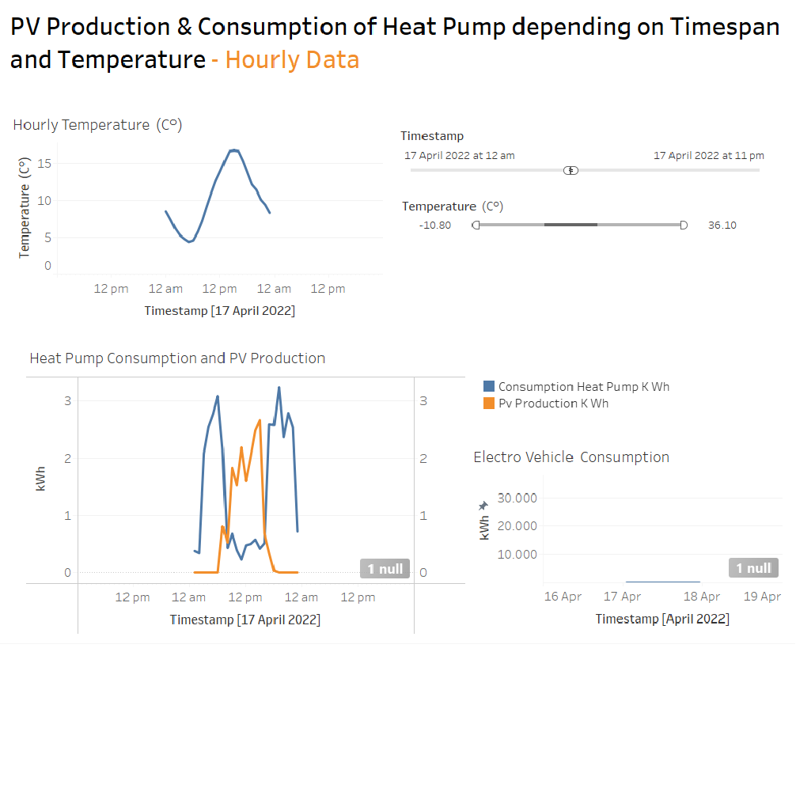

```r
knitr::include_graphics("images/hourly_few.png")
```

The second dashboard, Hourly View, presents the same variables, but this time at the hourly level. In the previous dashboard, all hourly values were aggregated to daily totals, while temperature was shown as a daily average. Here, you can directly observe what happens in a specific hour, giving a more detailed picture of energy behavior. The same filters for Date and Temperature are available, allowing the home owner to explore patterns more precisely and identify how short-term fluctuations affect both consumption and production.

### 7.3 Dashboard Forecast View

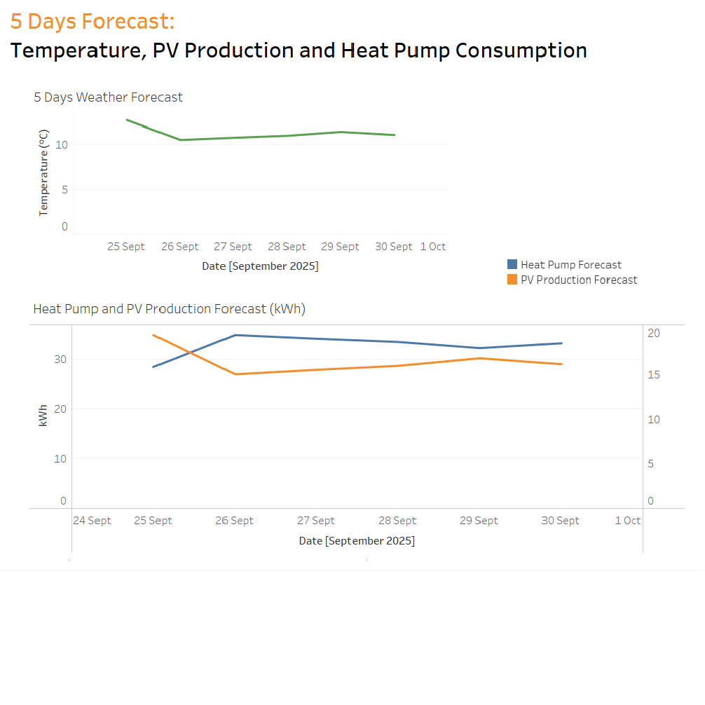

```r
knitr::include_graphics("images/forecast_few.png")
```

For the *Forecast View*, several additional steps were required. First, a new data source for the weather forecast was created. To achieve this, we registered at openweathermap.org in order to obtain a free API key. Using this API, the actual weather data (temperature only) was downloaded into a Google Sheet (the code for this process is available in our Git repository). We then established a live connection between Tableau and this Google Sheet. The Google Sheet was set up to refresh automatically every two hours, ensuring that the forecast data in Tableau stays up to date.

Afterwards, we created additional calculated variables in Tableau, such as Dayly Average Temperature, the Heat Pump Forecast and the PV Production Forecast.

The *Daily Average Temperature* had to be created because the new weather forecast in the Google Sheet provided temperature values every three hours. Earlier analysis had already shown that hourly data did not correlate as strongly with energy variables as daily averages did. This is understandable, since temperature fluctuates considerably within a single day, while the overall daily mean better reflects the relationship with energy consumption and production. To calculate this variable in Tableau, we used a FIXED LOD expression: DailyAvgTemp = { FIXED DATETRUNC(‘day’,[Date]) : AVG([Temperature (°C)]) }.

In the same way, we created the *PV Production Forecast*, based on the positive relationship between temperature and PV output. The formula was: PVForecast = –6.20 + 2.02 × [DailyAvgTemp].

These two calculated fields allowed us to transform the forecasted temperature values from the Google Sheet into predictions for both consumption and production.

It is important to note that these simple regression-based calculations cannot provide highly reliable predictions of heat pump consumption or PV production. In reality, many additional factors influence both outcomes, such as solar radiation, household usage patterns, or system efficiency. A more sophisticated forecasting model with multiple variables would therefore be required to achieve accurate results. Nevertheless, the approach presented here offers a useful first approximation and helps to illustrate how temperature alone can drive general patterns in energy consumption and production.

### 7.4 Dashboard Regression View

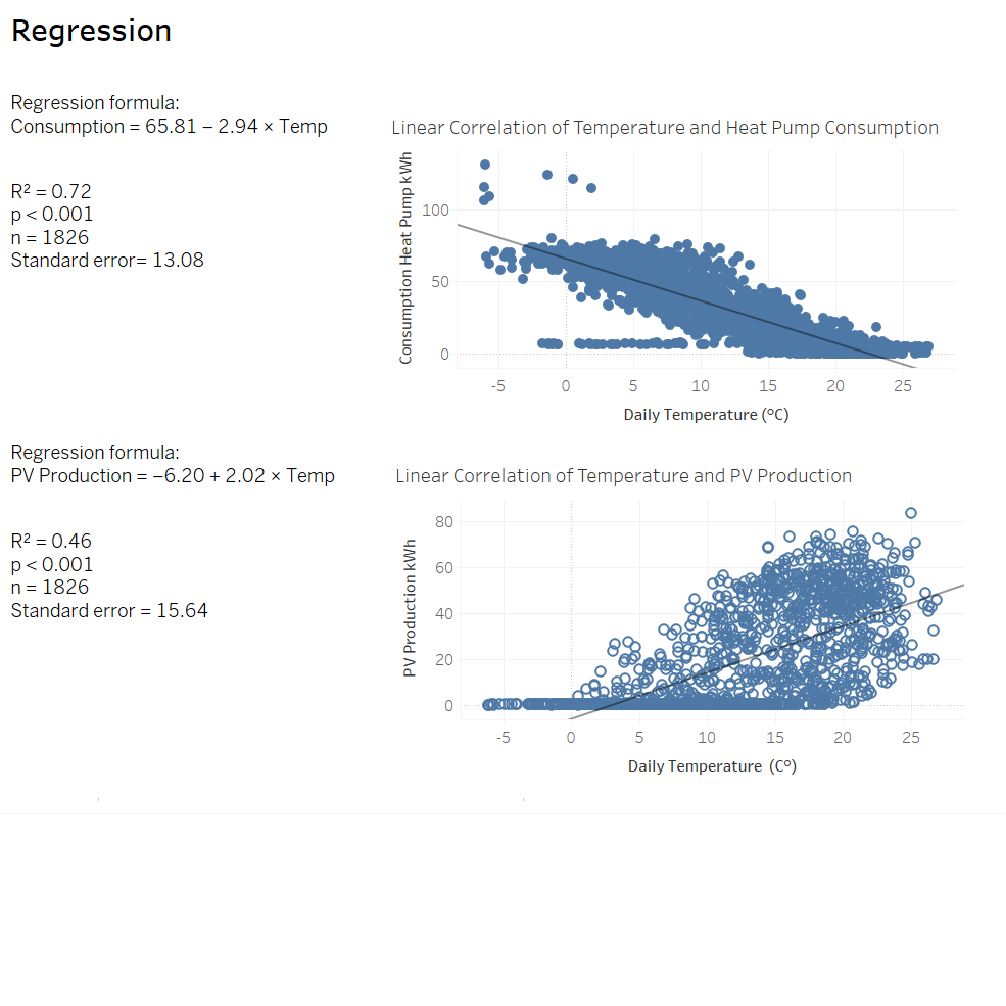

```r
knitr::include_graphics("images/analytics_few.png")
```

The results confirm that temperature is a strong predictor of heat pump consumption, as indicated by the high R² value, while it also explains part of the variation in PV production.

The final dashboards are published on Tableau Public and can be accessed at the following link:

https://public.tableau.com/app/profile/barbara.maier/viz/SustainabilityAnalytics.

Since Tableau Public works only with extracted data, the dashboards do not automatically update from the Google Sheet. To keep the forecast values current, the data sources have to be refreshed manually and the workbook re-published.

## 8. Results and Discussion

### 8.1 Conclusion: Answering the Research Question and Hypothesis

This analysis set out to determine in what ways a homeowner in Aargau could use their energy data to make better environmental and economic decisions. The answer is clear and multi-faceted: better decisions are made through a combination of **understanding** system dynamics, **acting** on behavioral changes, and **investing** in technology.

The findings of this report **strongly support the initial hypothesis**. The data confirms that the homeowner can significantly increase self-consumption and reduce grid dependency through data-driven strategies. Specifically, the analysis quantifies a large, predictable solar energy surplus during sunnier months. It demonstrates that aligning the flexible load of the electric vehicle with peak solar production is a highly effective, immediate strategy. Furthermore, the daily potential analysis provides concrete evidence that a well-sized battery storage system (10-15 kWh) would successfully shift this surplus energy to cover evening and nighttime demand, further validating the core components of the hypothesis.

### 8.2 Limitations of the Analysis

To provide a responsible assessment, it is crucial to be critically aware of this analysis’s boundaries.

#### 8.2.1 Data and Modeling Constraints

- **Absence of Solar Irradiance Data**: The analysis uses temperature as a proxy for solar potential. The lack of direct solar irradiance data—the measure of actual solar power—prevents a truly accurate model of PV generation.
- **Equipment and System Unknowns**: The report analyzes data without specific information on the hardware. The age, efficiency, and maintenance history of the PV panels and heat pump are unknown.
- **Microclimate Mismatch**: Weather data is from a local station, not the specific property, overlooking potential microclimate effects like shading from nearby trees.

#### 8.2.2 Absence of a Triple Bottom Line (3P) Analysis

A key limitation is the report’s narrow focus on technical energy flows, omitting a holistic **Triple Bottom Line**assessment, which is highly relevant due to public policies and subsidies in Switzerland.

- **Profit (Economic Viability)**: The report does not calculate the **Return on Investment (ROI)** for the battery system and ignores the significant impact of **public subsidies** (e.g., from Pronovo) that can alter economic feasibility.
- **People (Social Impact)**: The recommendations for high-capital investments overlook **social equity**. The suggestion to shift appliance usage also presumes a level of lifestyle flexibility that may not align with the occupants’ schedules or convenience.
- **Planet (Environmental Impact)**: The analysis assumes maximizing self-consumption is inherently best for the environment. This is incomplete, as it ignores the **lifecycle environmental cost** (embodied carbon) of manufacturing and disposing of a lithium-ion battery.

#### 8.2.3. Deliberate Scope and Project Focus

The limitations described are the result of a **conscious decision to define the project’s scope**. This analysis was framed as a **technical feasibility study** to identify energy patterns. This technical work serves as a **foundational baseline** that must be established before any meaningful financial or lifecycle assessment can be performed. This choice respects a **separation of expertise**, as a full 3P assessment requires an interdisciplinary team.

## 9. Outlook

This report transforms five years of historical data into an actionable roadmap for the homeowner, providing a clear, evidence-based strategy for enhancing energy self-sufficiency. The analysis is a starting point for informed action.

The most immediate, high-impact step is to shift electric vehicle charging to midday hours. This simple behavioral change directly converts surplus solar power into self-consumed transportation fuel, maximizing the value of the PV system.

Beyond this, the report serves as an evidence-based briefing document for engaging with professionals. The homeowner can use this data to:

- Consult a solar installer to diagnose and address the PV system’s significant underperformance in winter.
- Request precise quotes for a 10-15 kWh battery system, using this analysis to validate the required capacity.

By implementing these data-driven strategies, the homeowner can transition from a passive consumer to an active manager of their own energy ecosystem. This analysis provides the foundation to increase energy independence, reduce costs, and create a more sustainable and resilient household.

## 10. GenAI Declaration

In this project, we used AI tools (mainly ChatGPT) to support code revision and report writing. Examples include:

- Refining code syntax and improving ggplot visualizations
- Debugging errors and warnings
- Clarifying explanations, such as model interpretations

All AI suggestions were tested and reviewed before inclusion to ensure accuracy. Overall, AI was helpful, but careful verification was essential.

Amusan, J. A., & Otokunefor, E. B. (2019). The effect of cloud on the output performance of a solar module. *International Journal of Scientific and Engineering Research*. https://www.researchgate.net/publication/368858785_The_Effect_of_Cloud_on_the_Output_Performance_of_a_Solar_Module

Fachrizal, R., Shepero, M., Munkhammar, J., & Widén, J. (2020). Smart charging of electric vehicles considering PV, loads and battery storage: A heuristic approach. *Energies*, *13*(5), 1153. https://doi.org/10.3390/en13051153

Gu, X., Qian, K., & Yang, X. (2025). Reinforcement learning-based optimization of EV charging and discharging considering PV generation and battery health. *World Electric Vehicle Journal*, *16*(5), 286. https://doi.org/10.3390/wevj16050286

Mokhtari, A. et al. (2021). Investigating the effect of cloud cover on radiative cooling and solar PV performance. *Frontiers in Energy Research*, *9*, 658338. https://doi.org/10.3389/fenrg.2021.658338

Nahim, H. M. et al. (2025). Optimizing solar panel tilt angles for enhanced energy production. *Renewable Energy (Elsevier)*. https://www.sciencedirect.com/science/article/pii/S2214157X25009803

Sarmah, P. et al. (2023). Comprehensive analysis of solar panel performance under low-light and cold conditions. *Energies*. https://pmc.ncbi.nlm.nih.gov/articles/PMC10733962/

Shaker, L. M. et al. (2024). Examining the influence of thermal effects on solar cells: A review. *Sustainable Energy Research*. https://sustainenergyres.springeropen.com/articles/10.1186/s40807-024-00100-8

Solar, L. (2017). *The seasonality of solar energy production*. Blog post. https://www.lighthousesolarny.com/blog/2017/february/the-seasonality-of-solar-energy-production/

Ullner, R., Koch, S., & Andersson, G. (2025). Algorithmic control for residential energy systems with PV and EVs: A reinforcement learning approach. *arXiv Preprint*. https://arxiv.org/abs/2505.20377

U.S. Department of Energy. (2023). *Solar photovoltaic hardening for resilience – winter weather*. https://www.energy.gov/femp/solar-photovoltaic-hardening-resilience-winter-weather

Ye, M., Chen, T., Hu, J., & Zhang, C. (2024). Coordinated EV charging with PV systems in residential areas: A cost-minimization framework. *Energy Policy*, *187*, 113582. https://doi.org/10.1016/j.enpol.2024.113582